# How has COVID-19 affected Bay Area energy usage?(Assignment One)

For this report, we’ll investigate changes in energy usage in the Bay Area due to the novel coronavirus pandemic.

```r
library(tidyverse)
library(plotly)
library(sf)
library(tigris)
library(leaflet)
```

```r
years <- 2017:2020
quarters <- 1:4
types <- c("Electric","Gas")

pge_elec_gas <- NULL
pgefilter <- NULL

for(type in types){
  for(year in years){
    for(quarter in quarters) {
      if(year == 2020 && quarter == 4){
        next
      }

      filename <-
        paste0(
          "pge/PGE_",
          year,
          "_Q",
          quarter,
          "_",
          type,
          "UsageByZip.csv"
        )

      # print(filename)

      temp <- read_csv(filename)

      if(type == "Electric"){
        pge_final <-
            filter(
            temp,
            CUSTOMERCLASS %in%
              c(
              "Elec- Residential",
              "Elec- Commercial"
              )
            ) %>%
            mutate(
              TOTALKBTU =
              TOTALKWH*3.412
            )%>%
            select(
              !c(COMBINED, AVERAGEKWH,TOTALKWH)
            )  %>%
            group_by (MONTH,YEAR,CUSTOMERCLASS,ZIPCODE) %>%
            summarize(
              TOTALKBTU =
                sum(
                  TOTALKBTU,
                  na.rm = T
                ),
              TOTALCUSTOMERS =
                sum(
                TOTALCUSTOMERS,
                na.rm = T
                )
            ) %>%
            mutate(
              AVERAGEKBTU =
                TOTALKBTU/TOTALCUSTOMERS
            ) %>%
          mutate(
              DATE =
              paste(
                YEAR,
                MONTH,
                "01",
                sep="-"
              ) %>% as.Date()
          )
        pge_final
      }

      if(type == "Gas"){
        pge_final <-
            filter(
            temp,
            CUSTOMERCLASS %in%
              c(
              "Gas- Residential",
              "Gas- Commercial"
              )
            ) %>%
            mutate(
              TOTALKBTU =
              TOTALTHM*100
            )%>%
            select(
              !c(COMBINED, AVERAGETHM,TOTALTHM)
            )  %>%
            group_by (MONTH, YEAR, CUSTOMERCLASS,ZIPCODE) %>%
            summarize(
              TOTALKBTU =
                sum(
                  TOTALKBTU,
                  na.rm = T
                ),
              TOTALCUSTOMERS =
                sum(
                TOTALCUSTOMERS,
                na.rm = T
                )
            ) %>%
            mutate(
              AVERAGEKBTU =
                TOTALKBTU/TOTALCUSTOMERS
            ) %>%
            mutate(
              DATE =
              paste(
                YEAR,
                MONTH,
                "01",
                sep="-"
              ) %>% as.Date()
          )

        pge_final
      }


      pge_elec_gas <- rbind(pge_elec_gas,pge_final)
      # # Note rbind requires field names to be consistent for every new thing that you add.
      #
      saveRDS(pge_elec_gas, "pge_elec_gas.rds")
    }
  }
}

# head(pge_elec_gas)
```

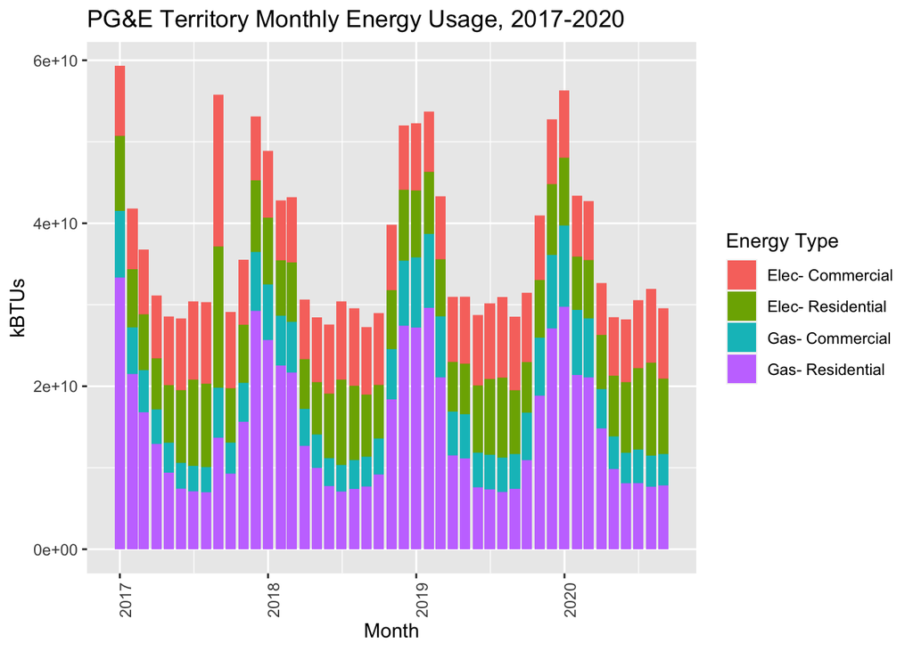

```r
pge_chart <-
  pge_elec_gas %>%
  ggplot()+
  geom_bar(
    aes(
      x = DATE %>% as.Date(),
      y = TOTALKBTU,
      fill = CUSTOMERCLASS
    ),
    stat = "identity",
    position = "stack"
  ) +
  labs(
    x = "Month",
    y = "kBTUs",
    title = "PG&E Territory Monthly Energy Usage, 2017-2020",
    fill = "Energy Type"
  ) +
  theme(
    axis.text.x = element_text(angle = 90)
  )
```

```r
pge_comm_elec_covid <- NULL
pge_covid_change <- NULL

bay_county_names <-
  c(
    "Alameda",
    "Contra Costa",
    "Marin",
    "Napa",
    "San Francisco",
    "San Mateo",
    "Santa Clara",
    "Solano",
    "Sonoma"
  )

bay_counties <-
  counties("CA", cb = T, progress_bar = F) %>%
  filter(NAME %in% bay_county_names)

usa_zips <-
  zctas(cb = T, progress_bar = F)

bay_zips <-
  usa_zips %>%
  st_centroid() %>%
  .[bay_counties, ]%>%
  st_set_geometry(NULL)%>%
  left_join(usa_zips %>% select(GEOID10)) %>%
  st_as_sf()

pge_comm_elec_covid <-
  pge_elec_gas %>%
  filter(YEAR %in% (2019:2020),MONTH %in% 3:6,CUSTOMERCLASS == "Elec- Residential") %>%
  mutate(
    ZIPCODE = ZIPCODE %>% as.character()
  ) %>%
  group_by(ZIPCODE,YEAR) %>%
  summarize(
    TOTALKBTU = sum(TOTALKBTU, na.rm = T)
  ) %>%
  pivot_wider(
    names_from = YEAR,
    values_from = TOTALKBTU
  ) %>%
  rename(
    KBTU2019 = "2019", KBTU2020 = "2020"
  ) %>%
  mutate(
    PERCENTCHANGE = ((KBTU2020 - KBTU2019)/KBTU2019) * 100
  ) %>%
  right_join(
    bay_zips %>% select(GEOID10),
    by = c("ZIPCODE" = "GEOID10")
  ) %>%
  subset(
    ., !ZIPCODE==94612
  ) %>%
  st_as_sf() %>%
  st_transform(4326)

res_pal <- colorNumeric(
  palette = "BuPu",
  domain =
    pge_comm_elec_covid$PERCENTCHANGE,
  reverse = FALSE,
  na.color = NA
)

leaflet() %>%
  addTiles() %>%
  addPolygons(
    data = pge_comm_elec_covid,
    fillColor = ~res_pal(PERCENTCHANGE),
    color = "white",
    opacity = 0.5,
    fillOpacity = 0.5,
    weight = 1,
    label = ~paste0(
      round(PERCENTCHANGE),
      "% kBTU change in ",
      ZIPCODE
    ),
    highlightOptions = highlightOptions(
      weight = 2,
      opacity = 1
    )
  ) %>%
  addLegend(
    data = pge_comm_elec_covid,
    pal = res_pal,
    values = ~PERCENTCHANGE,
    title = "Total Change in <br>Residential kBTU, <br> Compare Spring 2019  to 2020"
  )
```

[interactive chart not shown]

In order to determine changes in energy before and after the novel coronavirus pandemic, I compared residential energy usage from the same period of time (March through June) in 2019 and 2020. The start time chosen reflects the timing of the first shelter-in-place orders in the Bay Area and the end of time was chosen as the end to the Spring season. A different choice of months would result in different outcomes.  
**A note on data:** This data is aggregated to ensure data covers at least 100 residential customers, and in places where that is not the case, zip codes are combined, so the data may not be perfectly granular but works for this purpose of viewing general trends. I removed data for one zipcode in Oakland which showed an energy change of -68% which I classified as an outlier.  
Energy usage seemed to increase overall comparing Spring of 2019 to the Spring of 2020.The zipcodes with the largest area changes seemed to be clustered around San Rafael, Northeastern San Francisco, San Jose, Gilroy as well as Antioch and Brentwood.Surprisingly, Half Moon Bay and Pacifica area had smaller increases in energy usage (ranges from 2% to 6% in that area).